# Looking Ahead to Heating Prices at the Start of the Next Two Heating Seasons in Maine

Roux Institute - Analytics Capstone Spring 2022

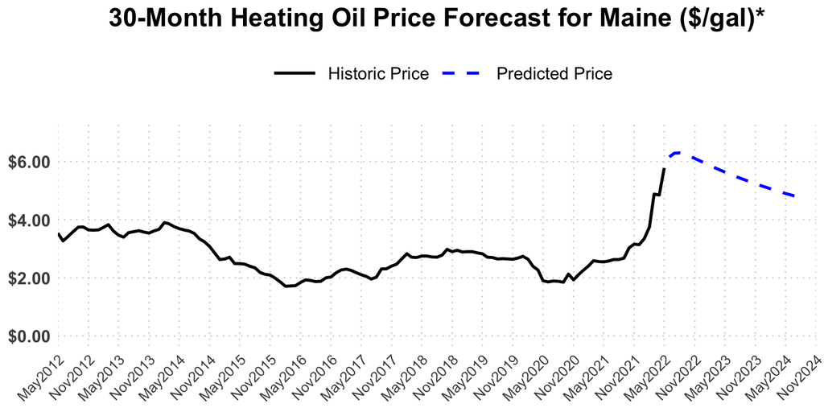

|  | Est. Price per Gallon* |
| --- | --- |
| Oct 2022 | $ 6.19 |
| Oct 2023 | $ 5.30 |

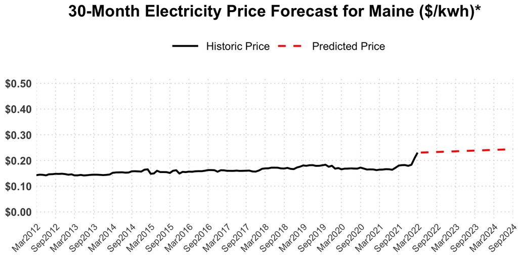

|  | Est. Price per kWh* |
| --- | --- |
| Oct 2022 | $ 0.233 |
| Oct 2023 | $ 0.239 |

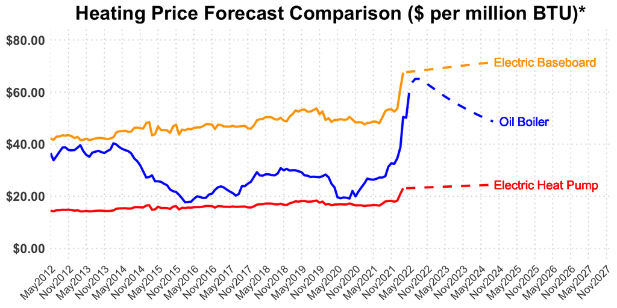

|  | Oct 2022 | Oct 2023 |
| --- | --- | --- |
| Electric Baseboard | $ 68.43 | $ 70.02 |
| Oil Boiler | $ 63.95 | $ 54.8 |
| Electric Heat Pump | $ 23.35 | $ 23.9 |

In **Oct 2022**, heating with an **oil boiler** is estimated to cost **2.7 x** more than heating with **electric heat pumps**,  
and heating with **electric baseboard heating** is estimated to cost **2.9 x** more than heating with **electric heat pumps**.

In **Oct 2023**, heating with an **oil boiler** is estimated to cost **2.3 x** more than heating with **electric heat pumps**,  
and heating with **electric baseboard heating** is estimated to cost **2.9 x** more than heating with **electric heat pumps**.

*Notes:

- *Historic heating oil prices obtained from the State of Maine Governor’s Energy Office data.*
- *Historic heating oil prices for non-heating-season months that were missing from the data were obtained by imputation using a linear regression model based on U.S. On-Highway Diesel Fuel Prices obtained from the U.S. Energy Information Administration.*
- *Heating oil prices predicted using an ARIMA(2,0,0) model, which has a 1-month forecast Mean Absolute Percentage Error (MAPE) of 3.44%, a 6-month forecast MAPE of 12.83%, and an 18-month forecast MAPE of 22.69%.*
- *Historic electricity prices obtained from the U.S. Energy Information Administration’s average monthly residential price, which is calculated by total revenue divided by the number of customers.*
- *Electricity prices predicted using a random walk with drift model, which has a 1-month forecast Mean Absolute Percentage Error (MAPE) of 1.51%, a 6-month forecast MAPE of 3.30%, and an 18-month forecast MAPE of 4.95%.*
- *Calculating dollars per million BTU for each heating type was performed using BTU’s per unit, system efficiencies, and distribution efficiencies obtained from Efficiency Maine.*